# Nearby and Deferred Quotes: What They Tell us About Linkages and Adjustments to Information

### Contemporaneous Correlation

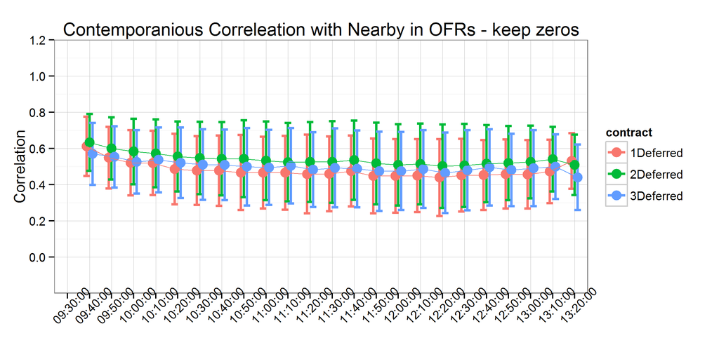

### Contemporaneous Correlation II

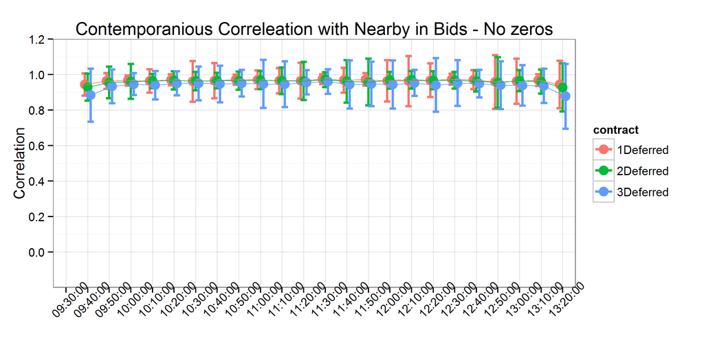

### Contemporaneous Correlation II

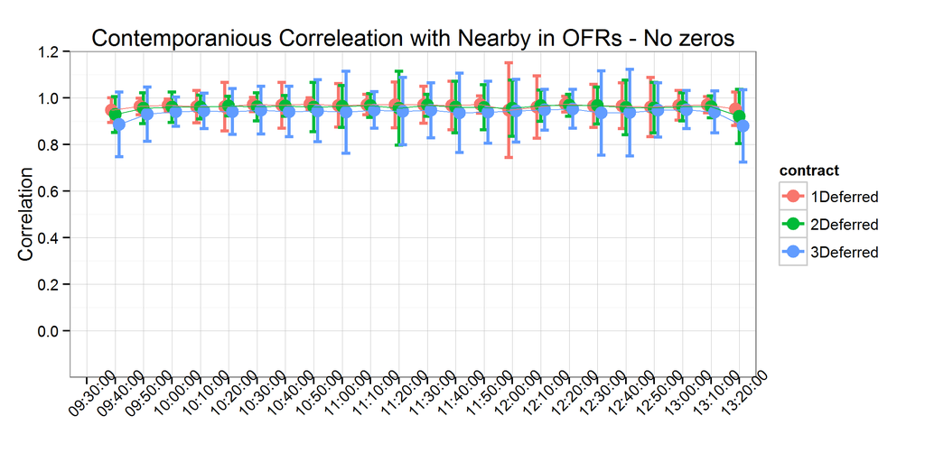

### Hypothesis: Liquidity Activity vs Information-Based Activity

- 'Keep Zeros' Includes many cases where the nearby's TOB was revised but the deferred's TOB was not (and vice versa)
- Whether this was a revision of a limit order or a transaction, the rest of the forward curve did not respond
- Making or taking liquidity - no information
  - Generates 'low correlation' activity

### Hypothesis: Liquidity Activity vs Information-Based Activity

- 'No Zeros', by contrast, only includes cases where the TOB of the nearby and deferred were revised simultaneously (as far as we can tell after aggregating to the second)
- These cases generate nearly perfect correlation.
- Information?
- This interpretation is consistent with the correlation between the nearby and the 1 deferred being lowest in the 'keep zeros' case
  - Relative to the other deferreds, the 1 deferred contract has the highest volume and (presumably) purely liquidity-based trading

### USDA Report Days?

- Recall that in our sub-sample (2010-2011), reports were released at 8:30am.
  - Before the start of the day trading session

### Contemporaneous Correlation

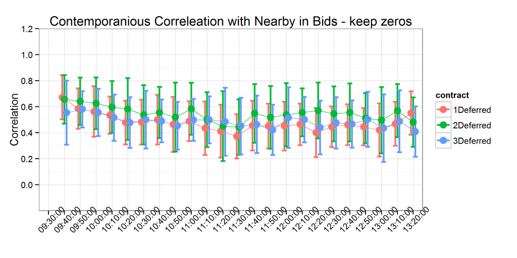

report days

### Contemporaneous Correlation

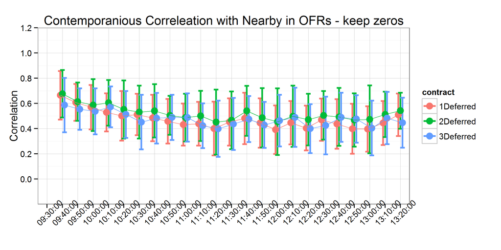

report days

### Contemporaneous Correlation II

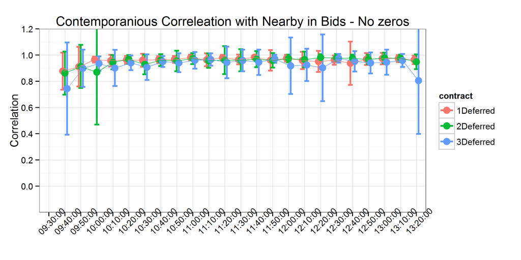

report days

### Contemporaneous Correlation II

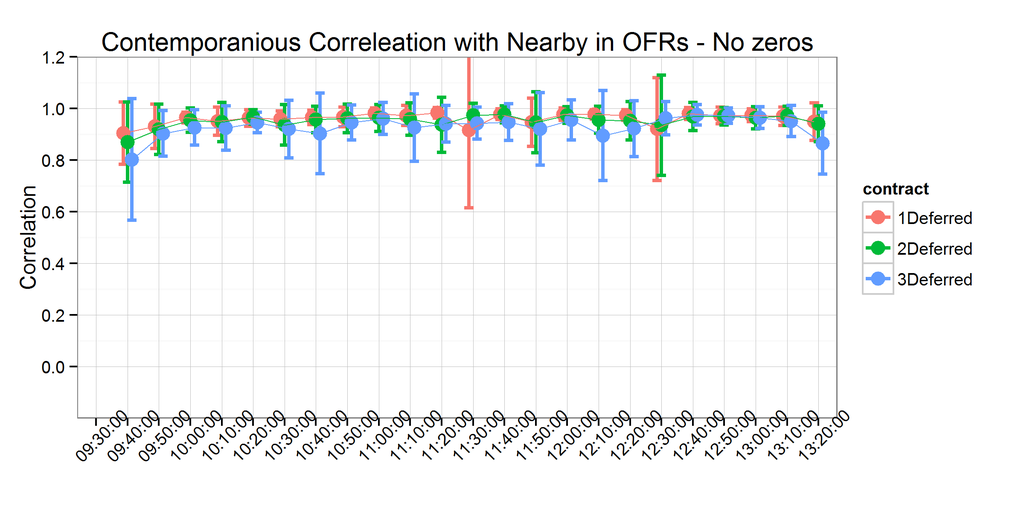

report days

### USDA Report Days?

- Very similar pattern as a typical day, with a slightly elevated correlation at the market open (indicating a higher than usual proportion of information based trading?)
  - This was surprising to us.
  - Interested to see 2012-2013 when reports are released at 11:00am.

### How Long Does the Correlation Persist?

- Lag nearby by 1 second (10 seconds) and calculate the same correlations with the 1 deferred contract

### Contemporaneous and Time Lagged Correlations

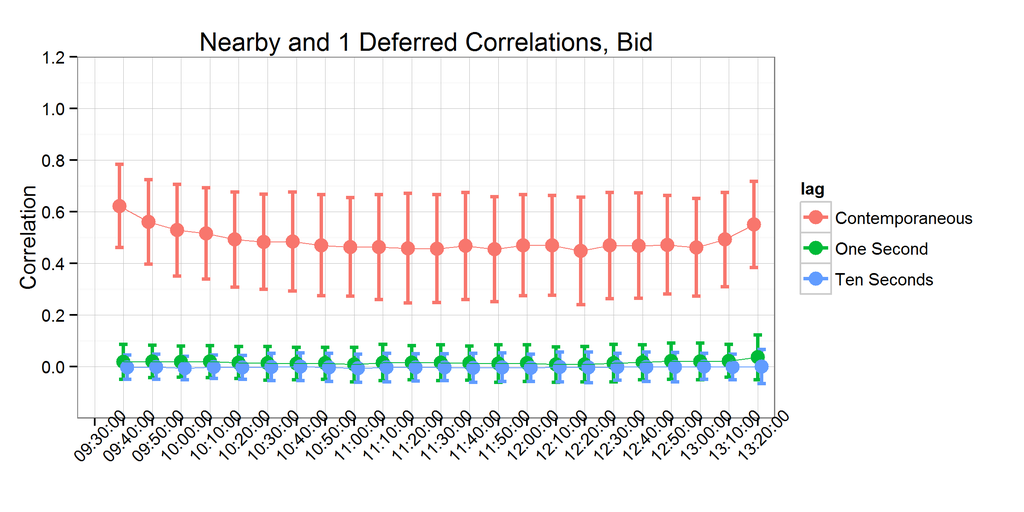

### Contemporaneous and Time Lagged Correlations

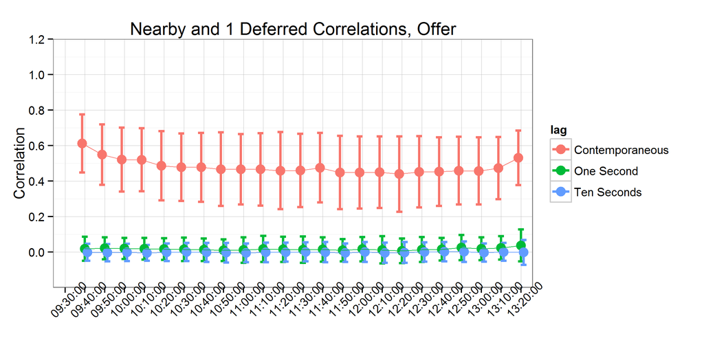

### Correlation Gone Immediately (1 sec)

Possible causes?

- HFT?
  - Anecdotally speaking, HFT did not seem that prevalent (at least not a lot of quote spoofing or pinging)
- Spread Trading
  - An order to the spread book affects both the nearby and deferred simultaneously

### Contemporaneous and Time Lagged Correlations

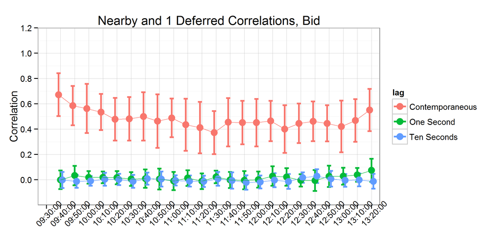

report days

### Contemporaneous and Time Lagged Correlations

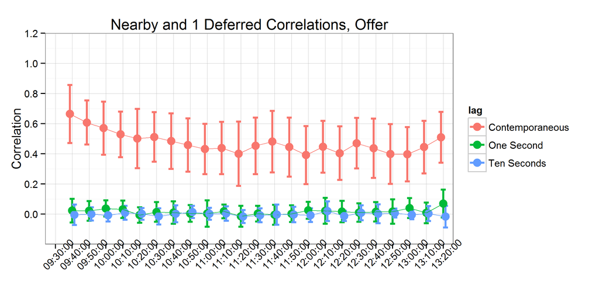

report days

### If Its Spread Traders...

Check Correlation of Bid-to-OFR and OFR-to-Bid

- Recall previous was Bid-to-Bid and OFR-to-OFR

### Contemporaneous Correlation

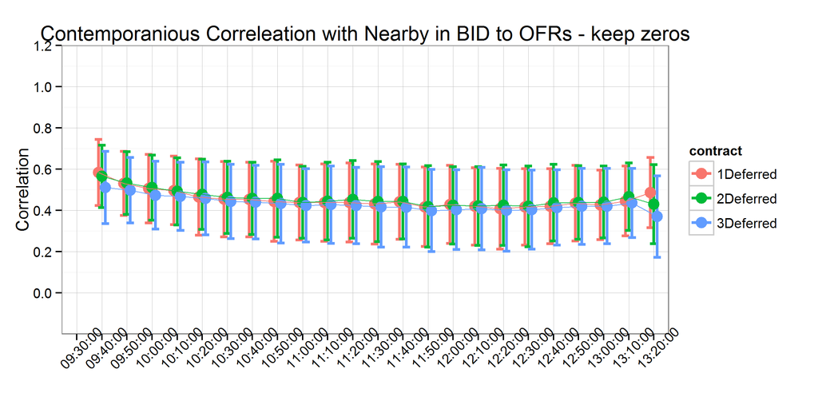

### Contemporaneous Correlation

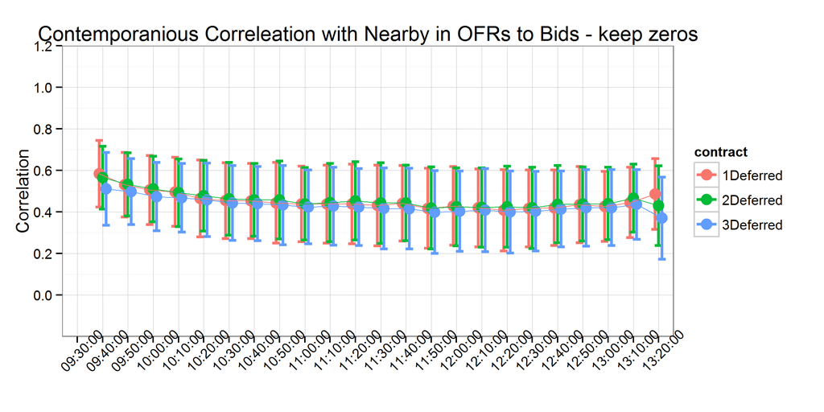

### Contemporaneous Correlation II

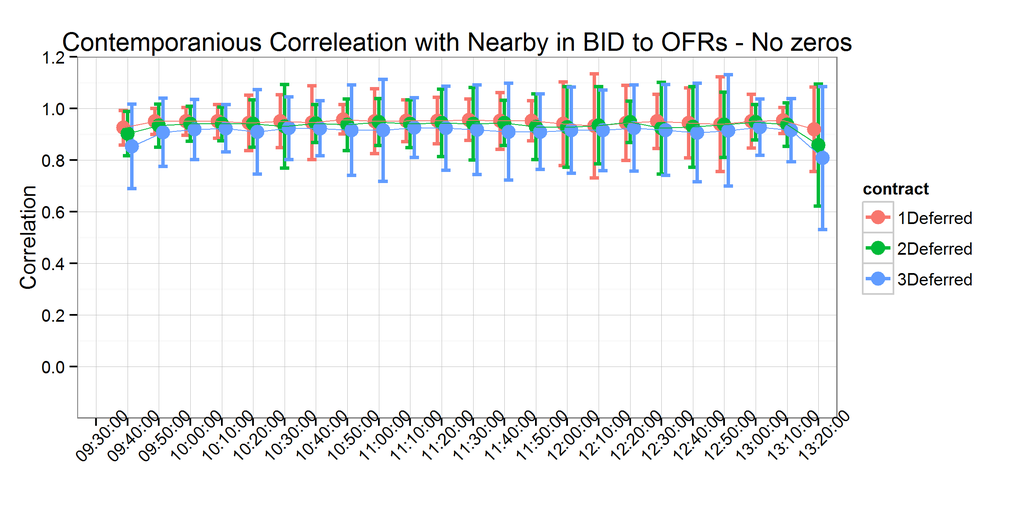

### Contemporaneous and Time Lagged Correlations

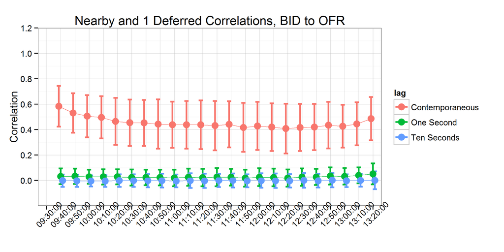

### Implications

- Nearby and deferred contract quotes appear to be highly correlated, even to the second
- Indicating an efficiency in the transmission of information up the forward curve
- Correlation does not persist past one second, indicating information has been fully incorporated

### Future Research

- More detailed quantification of the possible presence of HFT
- Apply the Probability of Informed Trader (PIN) model to the corn market to test the information hypothesis (Easley and O'Hara 1987)
- Of course, extend to more markets.

### Anecdotes about the Presence of HFT

### Number of Seconds to a Revision in Bid/Ask

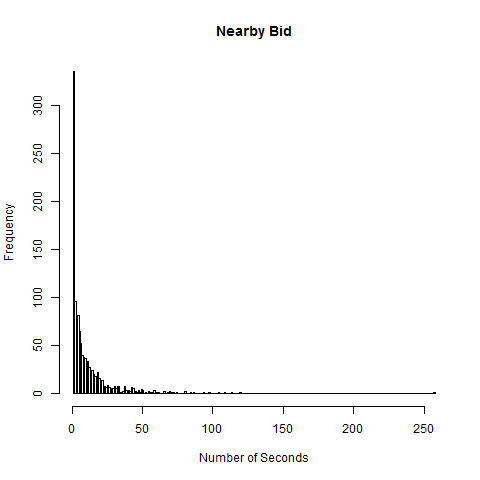

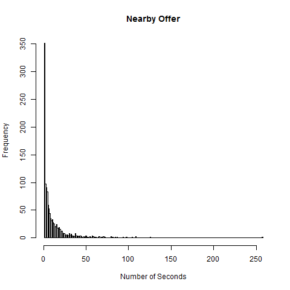

### Number of Seconds to a Revision in Bid/Ask

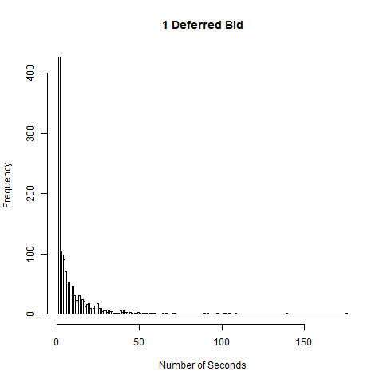

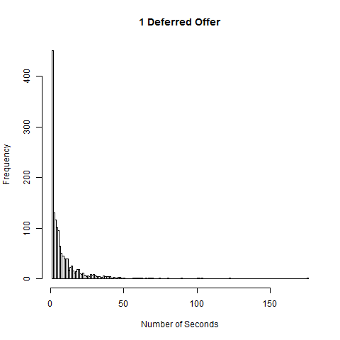

### Number of Seconds to a Revision in Bid/Ask

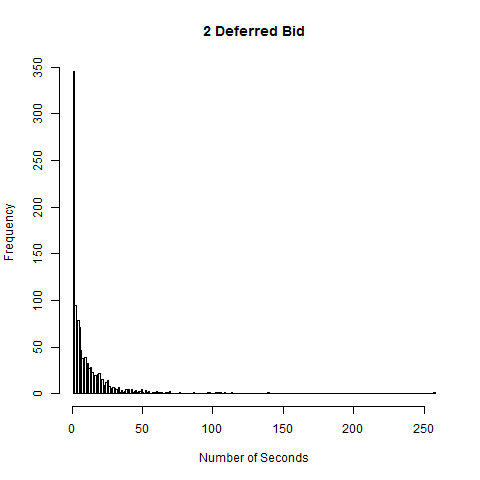

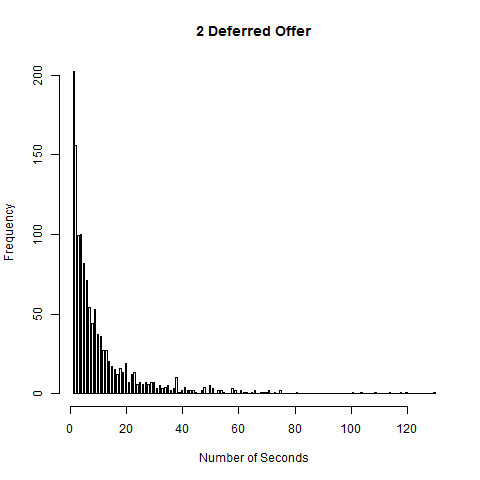

### Number of Seconds to a Revision in Bid/Ask

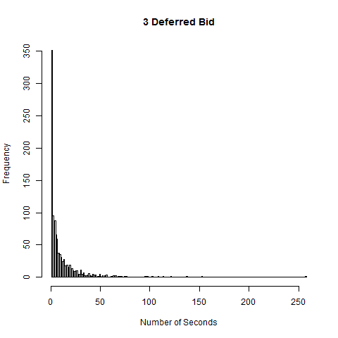

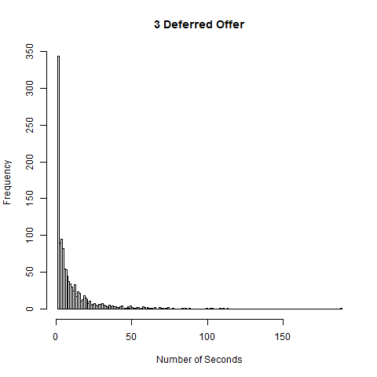